# Final Project

# Visualize Data

GGPLOT will be used in this part to visualize the data. In this section, the data will be split up first, to visualize the affects of only two conditions like (not)vacationing and (not)meditating.

## Not Vacationing and Not Meditating:

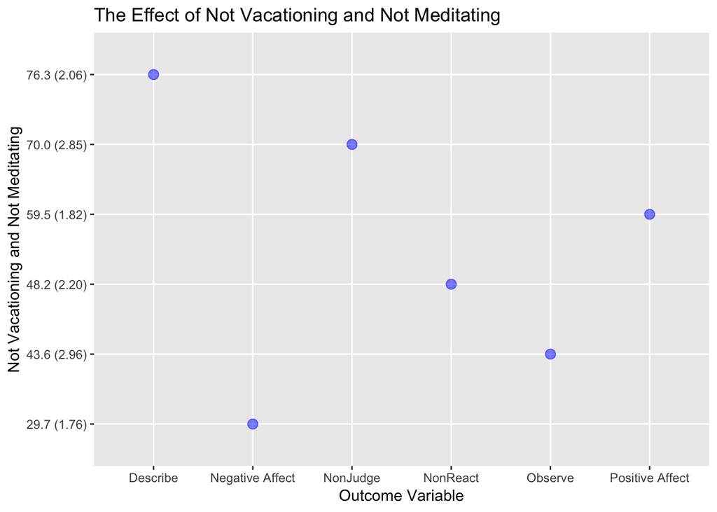

```r
ggplot(data = meditation) +
  geom_point(aes(x=Outcome.Variable, y=Not.Vacationing..Not.MeditatingM..SE.n.obs...1016), size=3,color="blue",alpha=0.5) +
  labs(title="The Effect of Not Vacationing and Not Meditating",x="Outcome Variable", y="Not Vacationing and Not Meditating")
```

Figure 1: This graph visualizes the data for what happens when individuals would not vacation and not meditate.

## Not Vacationing and Meditating

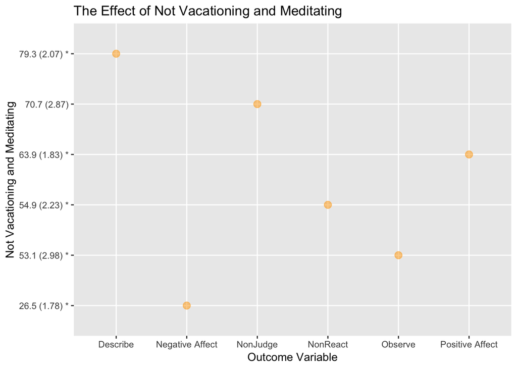

```r
ggplot(data = meditation) +
  geom_point(aes(x=Outcome.Variable, y=Not.Vacationing..MeditatingM..SE.n.obs...797), size=3,color="orange",alpha=0.5) +
  labs(title="The Effect of Not Vacationing and Meditating",x="Outcome Variable", y="Not Vacationing and Meditating")
```

Figure 2: This graph visualizes the data for what happens when individuals would not vacation and would meditate.

## Vacationing and Not Meditating

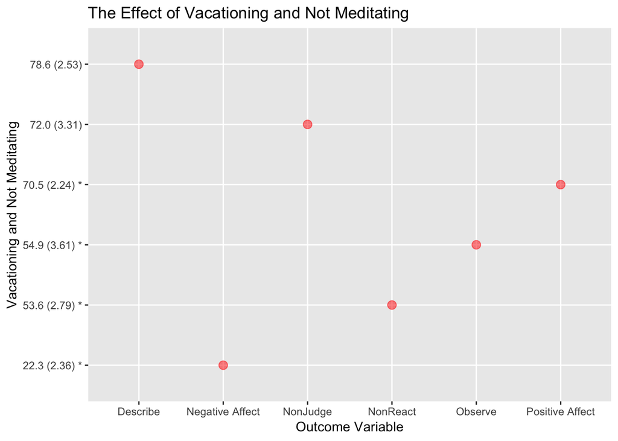

```r
ggplot(data = meditation) +
  geom_point(aes(x=Outcome.Variable, y=Vacationing..Not.MeditatingM..SE.n.obs...142), size=3,color="red",alpha=0.5) +
  labs(title="The Effect of Vacationing and Not Meditating",x="Outcome Variable", y="Vacationing and Not Meditating")
```

Figure 3: This graph visualizes the data for what happens when individuals would vacation and would not meditate.

## Vacationing and Meditating

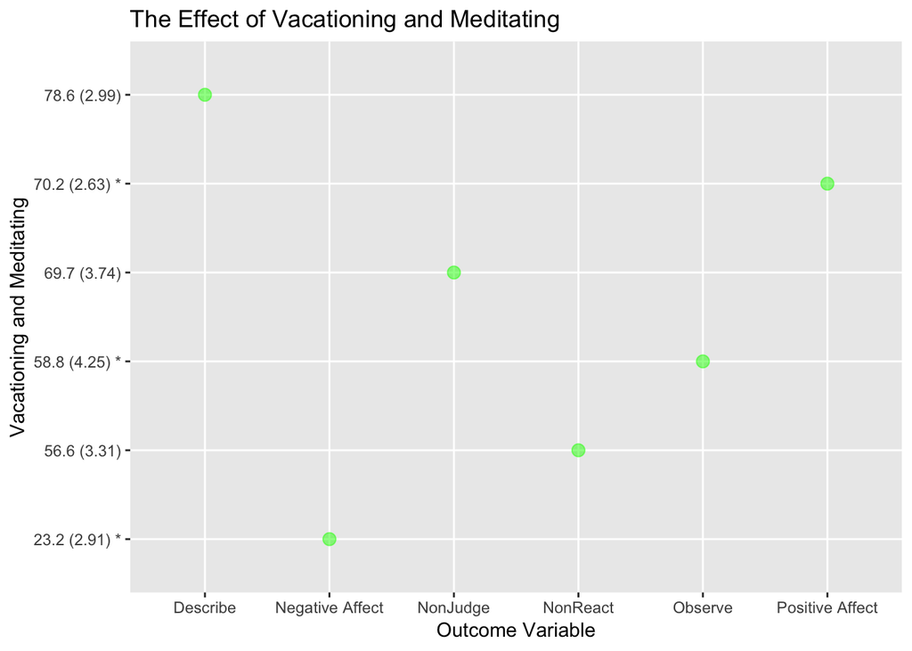

```r
ggplot(data = meditation) +
  geom_point(aes(x=Outcome.Variable, y=Vacationing..MeditatingM..SE.n.obs...67), size=3,color="green",alpha=0.5) +
  labs(title="The Effect of Vacationing and Meditating",x="Outcome Variable", y="Vacationing and Meditating")
```

Figure 4: This graph visualizes the data for what happens when individuals would vacation and meditate.